# STAT 184 FINAL PROJECT_CAR MPG

Sanghyon Jeong

12/2/2017

*Source file* ⇒ 184_FINAL_PROJECT.Rmd

# Data Description

The file “MPG.csv” contains data adapted from a dataset donated by StatLib library (Carnegie Mellon University) on https://archive.ics.uci.edu/ml/. The original data was composed on July 7, 1993 and was referenced to the following paper: Quinlan,R. (1993). Combining Instance-Based and Model-Based Learning. In Proceedings on the Tenth International Conference of Machine Learning, 236-243, University of Massachusetts, Amherst. Morgan Kaufmann.

This dataset is about a sample of 398 automobiles, descripting the relationships among mpg and the following variables:

1. mpg: miles per gallon index of each vehicle;
2. cylinders: number of cylinders of each vehicle;
3. displacement: displacement of each vehicle in kilo-miles;
4. horsepower: horsepower of each vehicle relevant to;
5. weight: weight of each vehicle in pound;
6. acceleration: seconds of each vehicle accelerates from 0 mph to 60 mph;
7. model year: year the car was made in yy
8. origin: Location of manufacture (1 - America; 2 - Europe; 3 - Asia)
9. car name: name of the car band and model

## First, read in the data and check.

```r
mpg <- read_csv("~/mpg.csv", col_types = cols(acceleration = col_number(), horsepower = col_number()))
str(mpg)
```

```
## Classes 'tbl_df', 'tbl' and 'data.frame':    398 obs. of  10 variables:
##  $ X1          : int  1 2 3 4 5 6 7 8 9 10 ...
##  $ mpg         : num  18 15 18 16 17 15 14 14 14 15 ...
##  $ cylinders   : int  8 8 8 8 8 8 8 8 8 8 ...
##  $ displacement: num  307 350 318 304 302 429 454 440 455 390 ...
##  $ horsepower  : num  130 165 150 150 140 198 220 215 225 190 ...
##  $ weight      : int  3504 3693 3436 3433 3449 4341 4354 4312 4425 3850 ...
##  $ acceleration: num  12 11.5 11 12 10.5 10 9 8.5 10 8.5 ...
##  $ model year  : int  70 70 70 70 70 70 70 70 70 70 ...
##  $ origin      : int  1 1 1 1 1 1 1 1 1 1 ...
##  $ car name    : chr  "chevrolet chevelle malibu" "buick skylark 320" "plymouth satellite" "amc rebel sst" ...
##  - attr(*, "problems")=Classes 'tbl_df', 'tbl' and 'data.frame': 6 obs. of  5 variables:
##   ..$ row     : int  33 127 331 337 355 375
##   ..$ col     : chr  "horsepower" "horsepower" "horsepower" "horsepower" ...
##   ..$ expected: chr  "a number" "a number" "a number" "a number" ...
##   ..$ actual  : chr  "?" "?" "?" "?" ...
##   ..$ file    : chr  "'~/mpg.csv'" "'~/mpg.csv'" "'~/mpg.csv'" "'~/mpg.csv'" ...
##  - attr(*, "spec")=List of 2
##   ..$ cols   :List of 10
##   .. ..$ X1          : list()
##   .. .. ..- attr(*, "class")= chr  "collector_integer" "collector"
##   .. ..$ mpg         : list()
##   .. .. ..- attr(*, "class")= chr  "collector_double" "collector"
##   .. ..$ cylinders   : list()
##   .. .. ..- attr(*, "class")= chr  "collector_integer" "collector"
##   .. ..$ displacement: list()
##   .. .. ..- attr(*, "class")= chr  "collector_double" "collector"
##   .. ..$ horsepower  : list()
##   .. .. ..- attr(*, "class")= chr  "collector_number" "collector"
##   .. ..$ weight      : list()
##   .. .. ..- attr(*, "class")= chr  "collector_integer" "collector"
##   .. ..$ acceleration: list()
##   .. .. ..- attr(*, "class")= chr  "collector_number" "collector"
##   .. ..$ model year  : list()
##   .. .. ..- attr(*, "class")= chr  "collector_integer" "collector"
##   .. ..$ origin      : list()
##   .. .. ..- attr(*, "class")= chr  "collector_integer" "collector"
##   .. ..$ car name    : list()
##   .. .. ..- attr(*, "class")= chr  "collector_character" "collector"
##   ..$ default: list()
##   .. ..- attr(*, "class")= chr  "collector_guess" "collector"
##   ..- attr(*, "class")= chr "col_spec"
```

## Since we have 6 missing values, remove rows with those missing values and recreate column names. Also delete car name variable since we do not need it for this project.

```r
mpg <- mpg[complete.cases(mpg),]
colnames(mpg) <- c("X1","mpg","cylinders","displacement","horsepower","weight","acceleration","model.year","origin","car.name")
mpg=subset(mpg,select=-c(X1,cylinders,car.name))
str(mpg)
```

```
## Classes 'tbl_df', 'tbl' and 'data.frame':    392 obs. of  7 variables:
##  $ mpg         : num  18 15 18 16 17 15 14 14 14 15 ...
##  $ displacement: num  307 350 318 304 302 429 454 440 455 390 ...
##  $ horsepower  : num  130 165 150 150 140 198 220 215 225 190 ...
##  $ weight      : int  3504 3693 3436 3433 3449 4341 4354 4312 4425 3850 ...
##  $ acceleration: num  12 11.5 11 12 10.5 10 9 8.5 10 8.5 ...
##  $ model.year  : int  70 70 70 70 70 70 70 70 70 70 ...
##  $ origin      : int  1 1 1 1 1 1 1 1 1 1 ...
```

## Now the dataset is ready. First, check for the assumptions on errors in order to apply a linear regression model.

```r
orig=factor(mpg$origin)
lm_full=lm(mpg$mpg~mpg$displacement+mpg$horsepower+mpg$weight+mpg$acceleration+mpg$model.year+orig)
summary(lm_full)
```

```
##
## Call:
## lm(formula = mpg$mpg ~ mpg$displacement + mpg$horsepower + mpg$weight +
##     mpg$acceleration + mpg$model.year + orig)
##
## Residuals:
##    Min     1Q Median     3Q    Max
## -8.729 -2.115 -0.021  1.923 13.292
##
## Coefficients:
##                    Estimate Std. Error t value Pr(>|t|)
## (Intercept)      -19.247521   4.607317  -4.178 3.65e-05 ***
## mpg$displacement   0.016436   0.005849   2.810  0.00521 **
## mpg$horsepower    -0.015629   0.013629  -1.147  0.25220
## mpg$weight        -0.006837   0.000651 -10.502  < 2e-16 ***
## mpg$acceleration   0.086660   0.098262   0.882  0.37837
## mpg$model.year     0.778280   0.051867  15.005  < 2e-16 ***
## orig2              2.591975   0.566840   4.573 6.50e-06 ***
## orig3              2.770110   0.550988   5.028 7.64e-07 ***
## ---
## Signif. codes:  0 '***' 0.001 '**' 0.01 '*' 0.05 '.' 0.1 ' ' 1
##
## Residual standard error: 3.312 on 384 degrees of freedom
## Multiple R-squared:  0.8231, Adjusted R-squared:  0.8199
## F-statistic: 255.3 on 7 and 384 DF,  p-value: < 2.2e-16
```

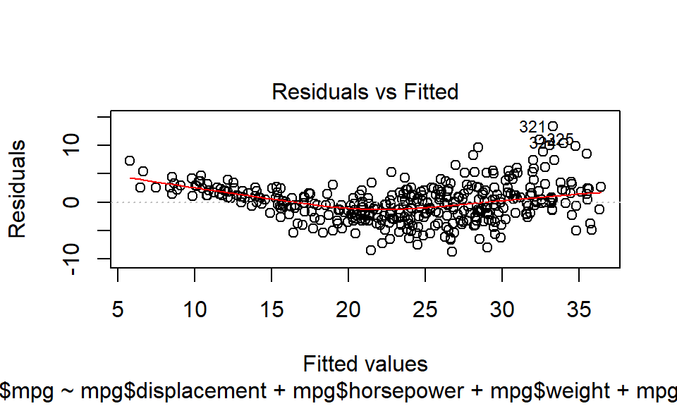

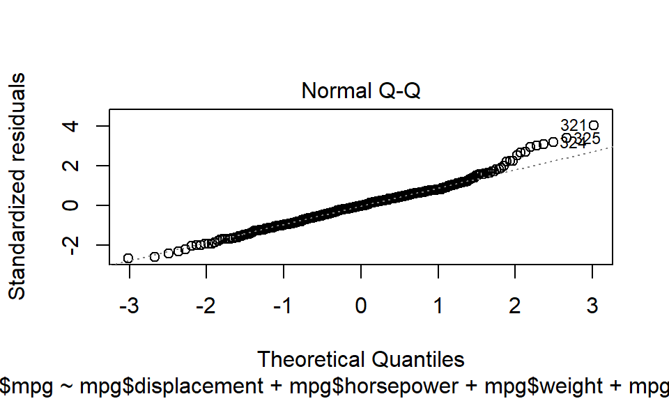

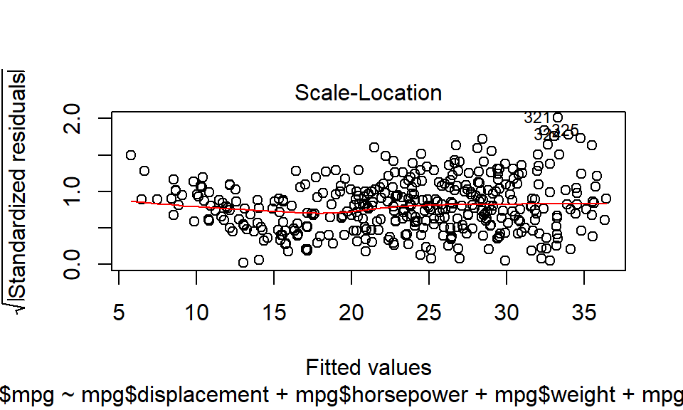

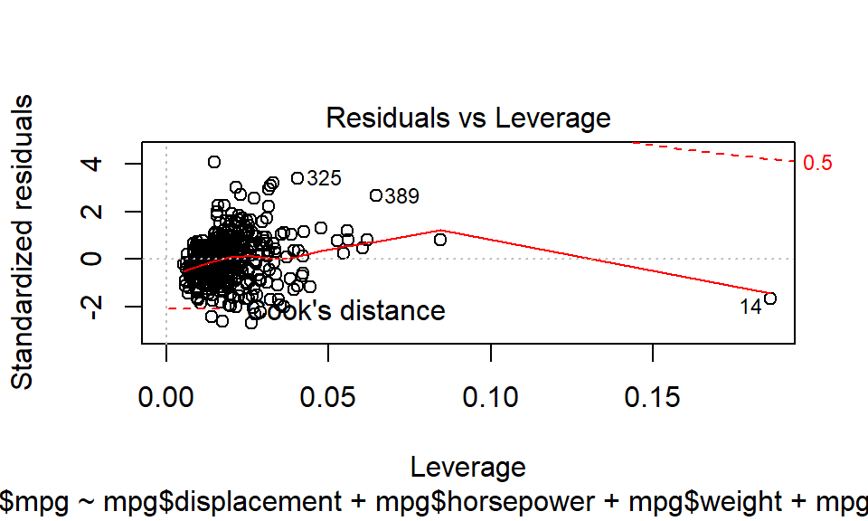

```r
plot(lm_full)
```

```r
shapiro.test(lm_full$residuals)
```

```
##
##  Shapiro-Wilk normality test
##
## data:  lm_full$residuals
## W = 0.98285, p-value = 0.0001331
```

## According to the residual versus fitted value plot, the assumptions on linearity, equal variance, and normality of errors seem to be violated. Therefore, transform both response and predictors.

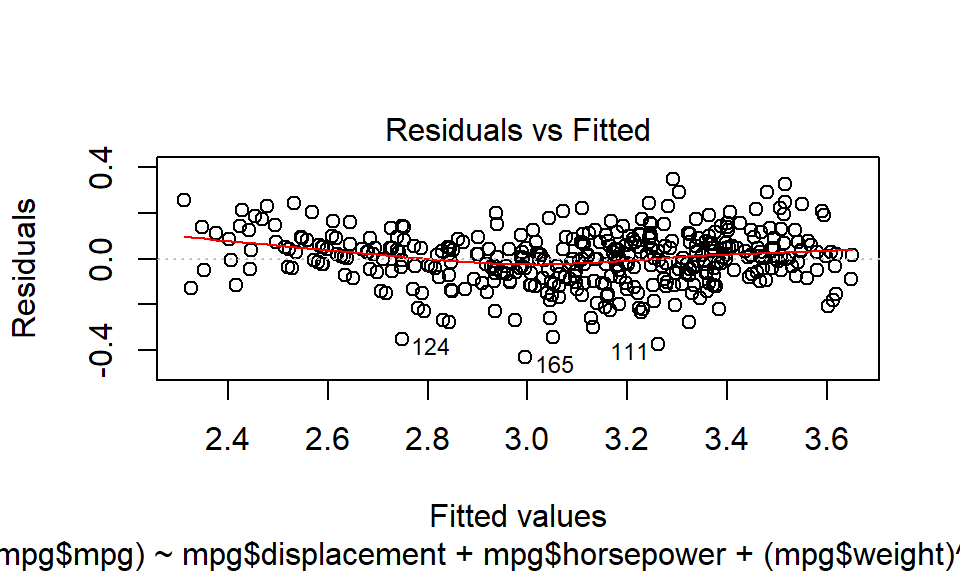

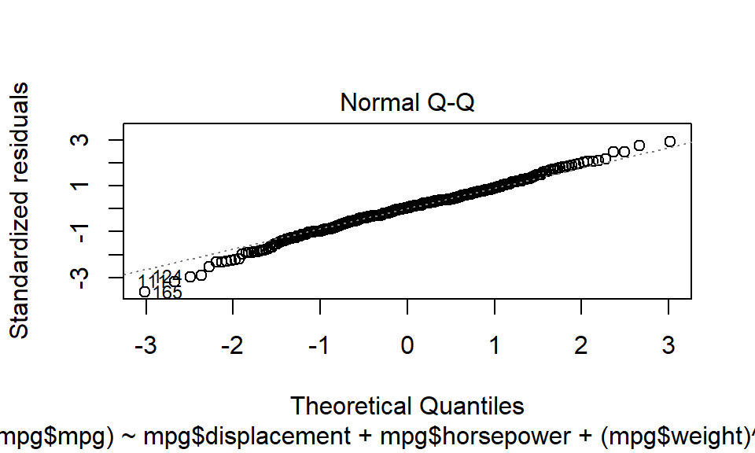

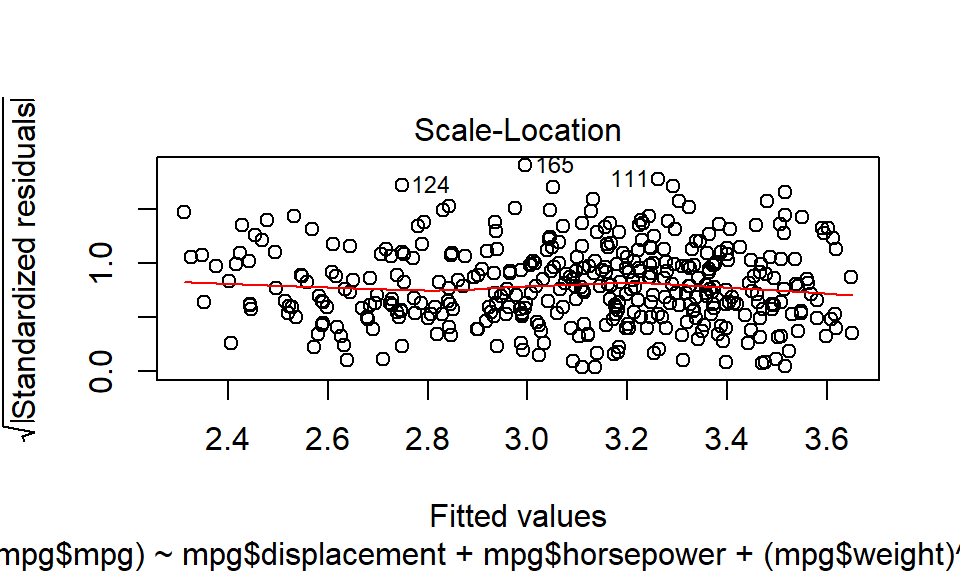

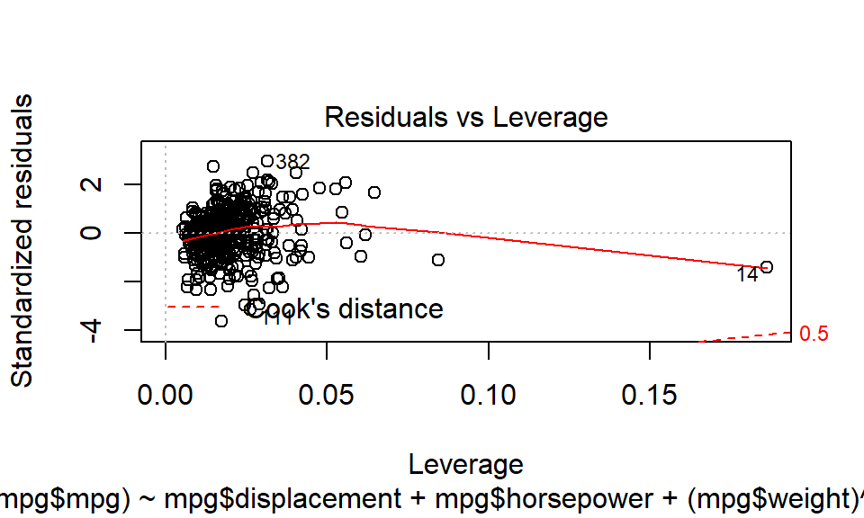

```r
lm_full1=lm(log(mpg$mpg)~mpg$displacement+mpg$horsepower+(mpg$weight)^2+mpg$acceleration+mpg$model.year+orig)
plot(lm_full1)
```

## We addressed non-linearity and non-constant variance of errors by transforming variables. However, we will investigate for the outliers that have strong influence on model.

```r
residuals=lm_full1$residuals
sigma_hat=summary(lm_full1)$sigma
X1=model.matrix(log(mpg$mpg)~mpg$displacement+mpg$horsepower+(mpg$weight)^2+mpg$acceleration+mpg$model.year+orig)
H=X1%*%solve(t(X1)%*%X1)%*%t(X1)
h=diag(H)
r=residuals/(sigma_hat*sqrt(1-h))
p=8
sum(h)
```

```
## [1] 8
```

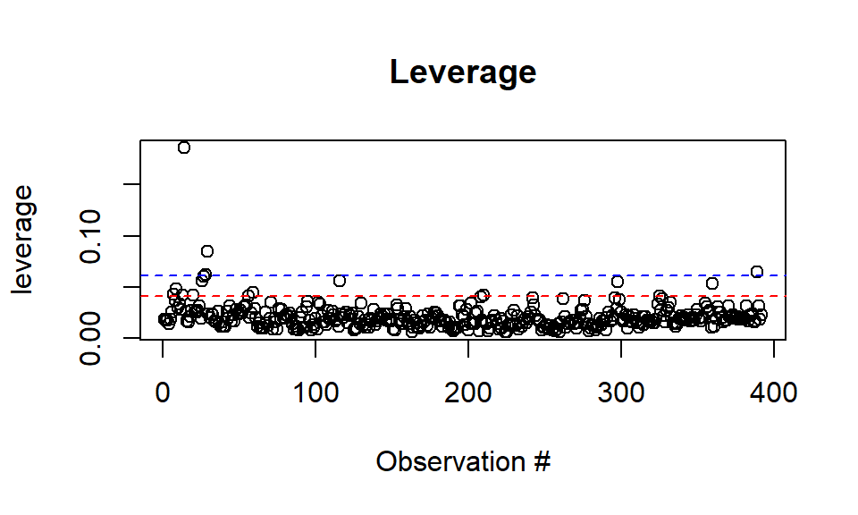

```r
n=nrow(mpg)
thresh2=2*p/n
thresh3=3*p/n
plot(h,xlab='Observation #',ylab='leverage',main='Leverage')
abline(h=thresh2,lty=2,col='red')
abline(h=thresh3,lty=2,col='blue')
```

```r
which(h>thresh3)
```

```
##  14  28  29 389
##  14  28  29 389
```

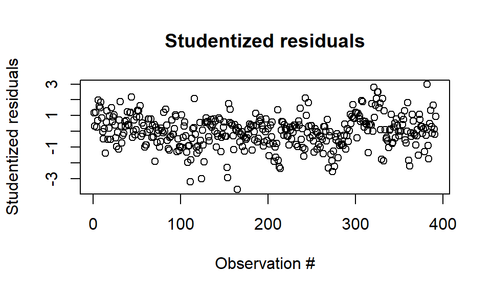

```r
t=r*sqrt((n-p-1)/(n-p-r^2))
plot(t,xlab="Observation #",ylab="Studentized residuals",main="Studentized residuals")
```

```r
which(abs(t)>3)
```

```
## 111 124 165
## 111 124 165
```

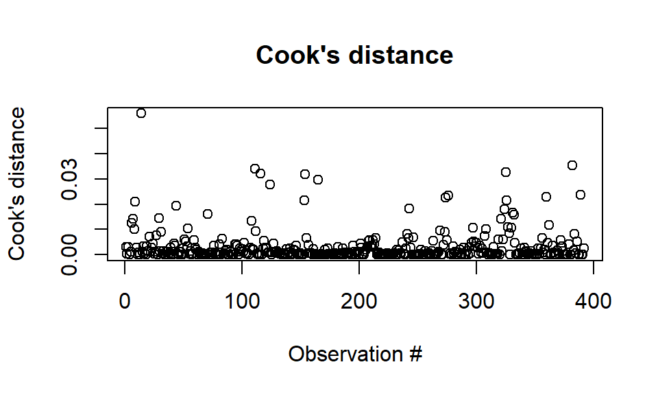

```r
D1=(1/p)*r^2*h/(1-h)
plot(D1,xlab="Observation #",ylab="Cook\'s distance",main="Cook\'s distance")
```

```r
which(D1>0.04)
```

```
## 14
## 14
```

## According to the leverage and cook’s distnace, we can check that the 14th observation is an outlier that influence the model. Therefore, we delete the 14th observation from the data set.

```r
mpg1=mpg[-c(14),]
```

## With the new data set, create the new model lm_full2 and check for multicollinearities.

```r
orig1=factor(mpg1$origin)
lm_full2=lm(log(mpg1$mpg)~mpg1$displacement+mpg1$horsepower+(mpg1$weight)^2+mpg1$acceleration+mpg1$model.year+orig1)
vif(lm_full2)
```

```
##                        GVIF Df GVIF^(1/(2*Df))
## mpg1$displacement 14.065154  1        3.750354
## mpg1$horsepower   10.277282  1        3.205820
## mpg1$weight       12.981532  1        3.602989
## mpg1$acceleration  2.724669  1        1.650657
## mpg1$model.year    1.298156  1        1.139366
## orig1              2.084227  2        1.201535
```

## Drop the displacement variable since it has the largest VIF and create the new model without displacement variable.

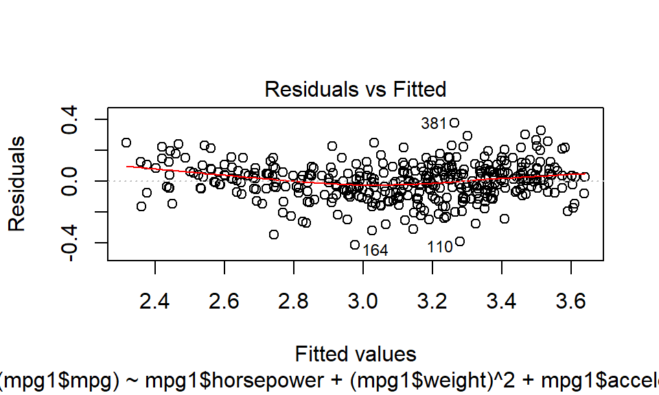

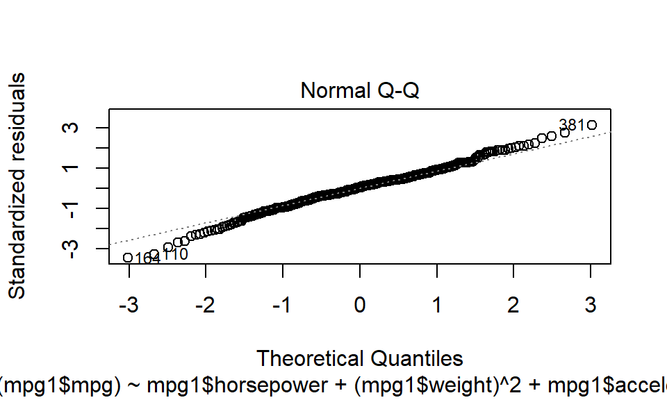

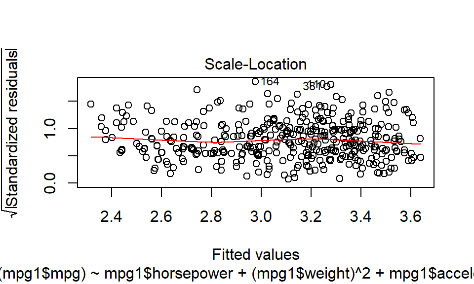

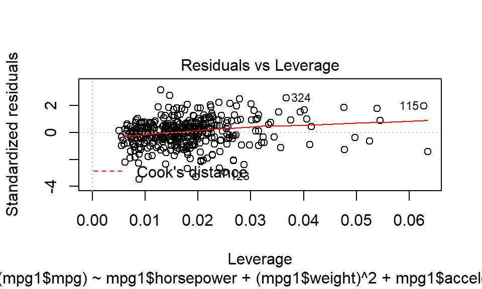

```r
lm_full3=lm(log(mpg1$mpg)~mpg1$horsepower+(mpg1$weight)^2+mpg1$acceleration+mpg1$model.year+orig1)
plot(lm_full3)
```

## Since the residual versus fitted plot suggests that the assumptions on errors are now held, we move forward to stepwise model selection.

```r
summary(lm_full3)
```

```
##
## Call:
## lm(formula = log(mpg1$mpg) ~ mpg1$horsepower + (mpg1$weight)^2 +
##     mpg1$acceleration + mpg1$model.year + orig1)
##
## Residuals:
##      Min       1Q   Median       3Q      Max
## -0.41230 -0.06904  0.00474  0.06839  0.37438
##
## Coefficients:
##                     Estimate Std. Error t value Pr(>|t|)
## (Intercept)        1.655e+00  1.657e-01   9.989  < 2e-16 ***
## mpg1$horsepower   -9.870e-04  4.992e-04  -1.977 0.048725 *
## mpg1$weight       -2.509e-04  1.896e-05 -13.233  < 2e-16 ***
## mpg1$acceleration -1.449e-03  3.542e-03  -0.409 0.682714
## mpg1$model.year    3.016e-02  1.846e-03  16.336  < 2e-16 ***
## orig12             6.797e-02  1.864e-02   3.647 0.000302 ***
## orig13             6.414e-02  1.887e-02   3.399 0.000748 ***
## ---
## Signif. codes:  0 '***' 0.001 '**' 0.01 '*' 0.05 '.' 0.1 ' ' 1
##
## Residual standard error: 0.1194 on 384 degrees of freedom
## Multiple R-squared:  0.8784, Adjusted R-squared:  0.8765
## F-statistic: 462.5 on 6 and 384 DF,  p-value: < 2.2e-16
```

```r
lm_back1=update(lm_full3,.~.-mpg1$acceleration)
summary(lm_back1)
```

```
##
## Call:
## lm(formula = log(mpg1$mpg) ~ mpg1$horsepower + mpg1$weight +
##     mpg1$model.year + orig1)
##
## Residuals:
##      Min       1Q   Median       3Q      Max
## -0.41022 -0.06883  0.00651  0.06933  0.37474
##
## Coefficients:
##                   Estimate Std. Error t value Pr(>|t|)
## (Intercept)      1.626e+00  1.497e-01  10.858  < 2e-16 ***
## mpg1$horsepower -8.415e-04  3.499e-04  -2.405 0.016630 *
## mpg1$weight     -2.548e-04  1.636e-05 -15.574  < 2e-16 ***
## mpg1$model.year  3.020e-02  1.842e-03  16.398  < 2e-16 ***
## orig12           6.724e-02  1.853e-02   3.628 0.000324 ***
## orig13           6.352e-02  1.879e-02   3.381 0.000798 ***
## ---
## Signif. codes:  0 '***' 0.001 '**' 0.01 '*' 0.05 '.' 0.1 ' ' 1
##
## Residual standard error: 0.1192 on 385 degrees of freedom
## Multiple R-squared:  0.8784, Adjusted R-squared:  0.8768
## F-statistic: 556.2 on 5 and 385 DF,  p-value: < 2.2e-16
```

```r
lm_back2=update(lm_back1,.~.-mpg1$horsepower)
summary(lm_back2)
```

```
##
## Call:
## lm(formula = log(mpg1$mpg) ~ mpg1$weight + mpg1$model.year +
##     orig1)
##
## Residuals:
##      Min       1Q   Median       3Q      Max
## -0.42472 -0.07212  0.01085  0.07177  0.38238
##
## Coefficients:
##                   Estimate Std. Error t value Pr(>|t|)
## (Intercept)      1.528e+00  1.450e-01  10.538  < 2e-16 ***
## mpg1$weight     -2.871e-04  9.353e-06 -30.702  < 2e-16 ***
## mpg1$model.year  3.162e-02  1.756e-03  18.003  < 2e-16 ***
## orig12           6.874e-02  1.864e-02   3.688 0.000259 ***
## orig13           5.625e-02  1.866e-02   3.015 0.002744 **
## ---
## Signif. codes:  0 '***' 0.001 '**' 0.01 '*' 0.05 '.' 0.1 ' ' 1
##
## Residual standard error: 0.12 on 386 degrees of freedom
## Multiple R-squared:  0.8766, Adjusted R-squared:  0.8753
## F-statistic: 685.3 on 4 and 386 DF,  p-value: < 2.2e-16
```

```r
lm_empty=lm(log(mpg)~1,data=mpg1)
summary(lm_empty)
```

```
##
## Call:
## lm(formula = log(mpg) ~ 1, data = mpg1)
##
## Residuals:
##      Min       1Q   Median       3Q      Max
## -0.90226 -0.25178  0.03601  0.26781  0.74211
##
## Coefficients:
##             Estimate Std. Error t value Pr(>|t|)
## (Intercept)  3.09949    0.01718   180.4   <2e-16 ***
## ---
## Signif. codes:  0 '***' 0.001 '**' 0.01 '*' 0.05 '.' 0.1 ' ' 1
##
## Residual standard error: 0.3397 on 390 degrees of freedom
```

```r
pvalue_for1=numeric(6)
names(pvalue_for1)=c('horsepower', 'weight', 'acceleration', 'model.year', 'orig12', 'orig13')
pvalue_for1[1]=summary(update(lm_empty, .~.+horsepower))$coefficient[2,4]
pvalue_for1[2]=summary(update(lm_empty, .~.+(weight)^2))$coefficient[2,4]
pvalue_for1[3]=summary(update(lm_empty, .~.+acceleration))$coefficient[2,4]
pvalue_for1[4]=summary(update(lm_empty, .~.+model.year))$coefficient[2,4]
pvalue_for1[5]=summary(update(lm_empty, .~.+orig1))$coefficient[2,4]
pvalue_for1[6]=summary(update(lm_empty, .~.+orig1))$coefficient[3,4]
pvalue_for1
```

```
##    horsepower        weight  acceleration    model.year        orig12
## 1.815455e-101 4.499817e-126  2.582402e-20  8.834655e-36  2.007731e-17
##        orig13
##  1.066119e-29
```

### Add weight variable since it has the lowest pvalue

```r
lm_for1=update(lm_empty, .~.+(weight)^2)
summary(lm_for1)
```

```
##
## Call:
## lm(formula = log(mpg) ~ weight, data = mpg1)
##
## Residuals:
##      Min       1Q   Median       3Q      Max
## -0.50810 -0.10054 -0.00633  0.09900  0.55131
##
## Coefficients:
##               Estimate Std. Error t value Pr(>|t|)
## (Intercept)  4.143e+00  3.009e-02  137.67   <2e-16 ***
## weight      -3.504e-04  9.719e-06  -36.05   <2e-16 ***
## ---
## Signif. codes:  0 '***' 0.001 '**' 0.01 '*' 0.05 '.' 0.1 ' ' 1
##
## Residual standard error: 0.1632 on 389 degrees of freedom
## Multiple R-squared:  0.7696, Adjusted R-squared:  0.769
## F-statistic:  1300 on 1 and 389 DF,  p-value: < 2.2e-16
```

```r
pvalue_for2=numeric(5)
names(pvalue_for2)=c('horsepower', 'acceleration', 'model.year', 'orig12', 'orig13')
pvalue_for2[1]=summary(update(lm_for1, .~.+horsepower))$coefficient[3,4]
pvalue_for2[2]=summary(update(lm_for1, .~.+acceleration))$coefficient[3,4]
pvalue_for2[3]=summary(update(lm_for1, .~.+model.year))$coefficient[3,4]
pvalue_for2[4]=summary(update(lm_for1, .~.+orig1))$coefficient[3,4]
pvalue_for2[5]=summary(update(lm_for1, .~.+orig1))$coefficient[4,4]
pvalue_for2
```

```
##   horsepower acceleration   model.year       orig12       orig13
## 2.636714e-08 4.627957e-04 4.808595e-51 2.929135e-01 1.858751e-02
```

### Add model year variable since it has the lowest pvalue

```r
lm_for2=update(lm_for1, .~.+model.year)
summary(lm_for2)
```

```
##
## Call:
## lm(formula = log(mpg) ~ weight + model.year, data = mpg1)
##
## Residuals:
##      Min       1Q   Median       3Q      Max
## -0.44448 -0.06844  0.00177  0.06913  0.36360
##
## Coefficients:
##               Estimate Std. Error t value Pr(>|t|)
## (Intercept)  1.664e+00  1.433e-01   11.61   <2e-16 ***
## weight      -3.089e-04  7.648e-06  -40.39   <2e-16 ***
## model.year   3.100e-02  1.769e-03   17.52   <2e-16 ***
## ---
## Signif. codes:  0 '***' 0.001 '**' 0.01 '*' 0.05 '.' 0.1 ' ' 1
##
## Residual standard error: 0.1221 on 388 degrees of freedom
## Multiple R-squared:  0.8714, Adjusted R-squared:  0.8707
## F-statistic:  1314 on 2 and 388 DF,  p-value: < 2.2e-16
```

```r
pvalue_for3=numeric(4)
names(pvalue_for3)=c('horsepower', 'acceleration', 'orig12', 'orig13')
pvalue_for3[1]=summary(update(lm_for2, .~.+horsepower))$coefficient[4,4]
pvalue_for3[2]=summary(update(lm_for2, .~.+acceleration))$coefficient[4,4]
pvalue_for3[3]=summary(update(lm_for2, .~.+orig1))$coefficient[4,4]
pvalue_for3[4]=summary(update(lm_for2, .~.+orig1))$coefficient[5,4]
pvalue_for3
```

```
##   horsepower acceleration       orig12       orig13
##  0.033950169  0.124716324  0.000258536  0.002743849
```

### Add orig1 variables since it has the lowest pvalue

```r
lm_for3=update(lm_for2, .~.+orig1)
summary(lm_for3)
```

```
##
## Call:
## lm(formula = log(mpg) ~ weight + model.year + orig1, data = mpg1)
##
## Residuals:
##      Min       1Q   Median       3Q      Max
## -0.42472 -0.07212  0.01085  0.07177  0.38238
##
## Coefficients:
##               Estimate Std. Error t value Pr(>|t|)
## (Intercept)  1.528e+00  1.450e-01  10.538  < 2e-16 ***
## weight      -2.871e-04  9.353e-06 -30.702  < 2e-16 ***
## model.year   3.162e-02  1.756e-03  18.003  < 2e-16 ***
## orig12       6.874e-02  1.864e-02   3.688 0.000259 ***
## orig13       5.625e-02  1.866e-02   3.015 0.002744 **
## ---
## Signif. codes:  0 '***' 0.001 '**' 0.01 '*' 0.05 '.' 0.1 ' ' 1
##
## Residual standard error: 0.12 on 386 degrees of freedom
## Multiple R-squared:  0.8766, Adjusted R-squared:  0.8753
## F-statistic: 685.3 on 4 and 386 DF,  p-value: < 2.2e-16
```

```r
pvalue_for4=numeric(2)
names(pvalue_for4)=c('horsepower', 'acceleration')
pvalue_for4[1]=summary(update(lm_for3, .~.+horsepower))$coefficient[6,4]
pvalue_for4[2]=summary(update(lm_for3, .~.+acceleration))$coefficient[6,4]
pvalue_for4
```

```
##   horsepower acceleration
##   0.01663004   0.15651281
```

```r
lm_best=lm(log(mpg1$mpg)~mpg1$weight+mpg1$model.year+orig1)
summary(lm_best)
```

```
##
## Call:
## lm(formula = log(mpg1$mpg) ~ mpg1$weight + mpg1$model.year +
##     orig1)
##
## Residuals:
##      Min       1Q   Median       3Q      Max
## -0.42472 -0.07212  0.01085  0.07177  0.38238
##
## Coefficients:
##                   Estimate Std. Error t value Pr(>|t|)
## (Intercept)      1.528e+00  1.450e-01  10.538  < 2e-16 ***
## mpg1$weight     -2.871e-04  9.353e-06 -30.702  < 2e-16 ***
## mpg1$model.year  3.162e-02  1.756e-03  18.003  < 2e-16 ***
## orig12           6.874e-02  1.864e-02   3.688 0.000259 ***
## orig13           5.625e-02  1.866e-02   3.015 0.002744 **
## ---
## Signif. codes:  0 '***' 0.001 '**' 0.01 '*' 0.05 '.' 0.1 ' ' 1
##
## Residual standard error: 0.12 on 386 degrees of freedom
## Multiple R-squared:  0.8766, Adjusted R-squared:  0.8753
## F-statistic: 685.3 on 4 and 386 DF,  p-value: < 2.2e-16
```

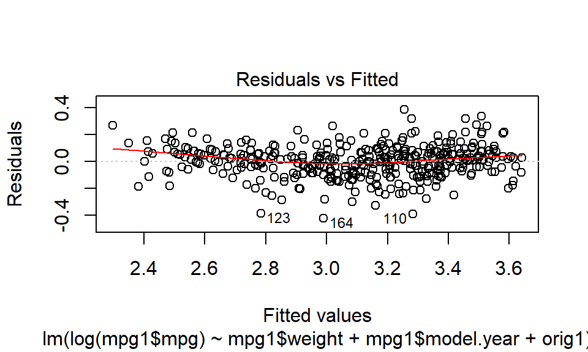

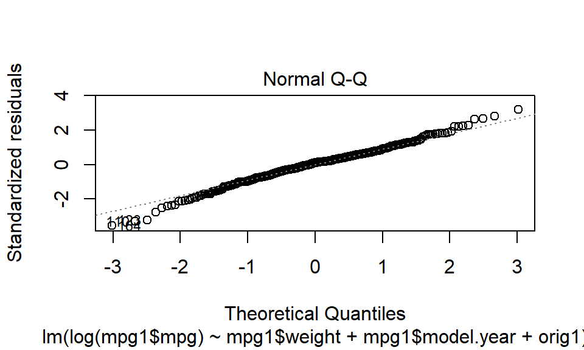

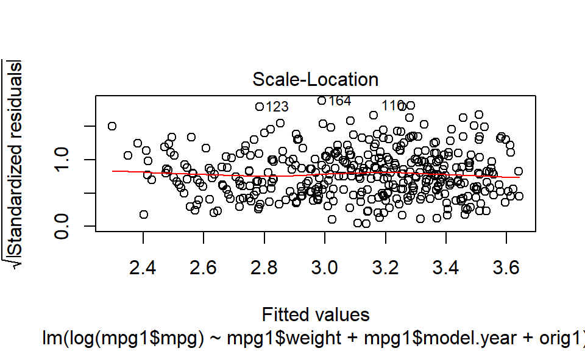

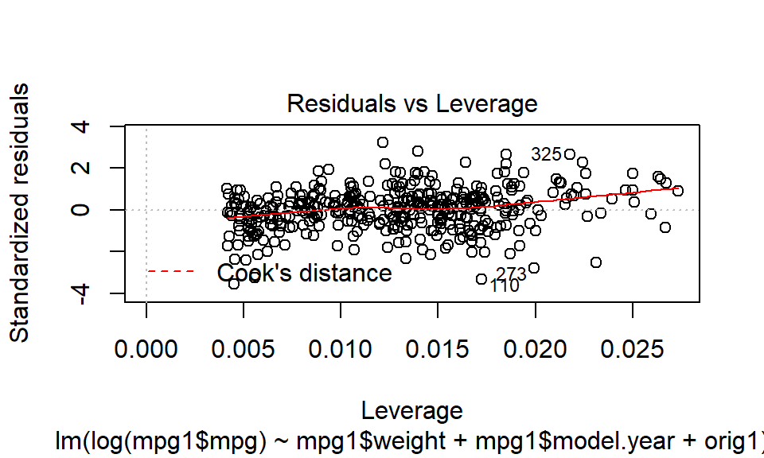

```r
plot(lm_best)
```